# Aufgabe 6: Unterschiedshypothese - Gruppe C

```r
library(dplyr)
library(ggplot2)
library(car)
library(sjstats)
library(lsr)
```

```r
library(readxl)
hosp6 <- read_excel("cleanhospital.xlsx")
View(hosp6)
```

### Datensatz: cleanhospital.xlsx

### Var 1 = fever (Faktor)

### Var 2 = age (AV)

## Aufgabenstellung

### Beschreibung

In der Regel wird davon ausgegangen, dass die Fähigkeit hoch zu fiebern mit dem Alter abnimmt. Dies hat mit dem altern des Immunsystems zu tun. Bei Patient*innen über 70 können bleibt bei ca. 20 bis 30 Prozent der ernsthaften Infektionen das Fieber ganz aus. Die Covid-19-Patient_innen in der Stichprobe wurden je nach Temperatur auf vier verschiedenen Gruppen aufgeteilt (normal, erhöht, fieber und hohes fieber). Nun wollten wir sehen, ob es einen Unterschied hinsichtlich der Mittelwerte beim Alter in den vier Gruppen gibt. Erwartungsgemäss sollte das Fieber bei den älteren Patient_innen eher niedrig sein.

```r
sum(is.na(hosp6))
```

```
[1] 4
```

```r
hosp6 = na.omit(hosp6)
sum(is.na(hosp6))
```

```
[1] 0
```

```r
table(hosp6$fever)
```

```
     erhoeht       fieber hohes fieber       normal
          37           67           27           79
```

```r
library(PMCMRplus)
x <- hosp6$age
g <- factor(hosp6$fever)
fit <- aov(x ~ g)
shapiro.test(residuals(fit))
```

```
    Shapiro-Wilk normality test

data:  residuals(fit)
W = 0.98505, p-value = 0.02565
```

```r
bartlett.test(x ~ g)
```

```
    Bartlett test of homogeneity of variances

data:  x by g
Bartlett's K-squared = 0.29552, df = 3, p-value = 0.9609
```

```r
anova(fit)
```

```
Analysis of Variance Table

Response: x
           Df Sum Sq Mean Sq F value Pr(>F)
g           3   1664  554.77  2.4132 0.0678 .
Residuals 206  47358  229.89
---
Signif. codes:  0 ‘***’ 0.001 ‘**’ 0.01 ‘*’ 0.05 ‘.’ 0.1 ‘ ’ 1
```

```r
## works with object of class aov
summary(tamhaneDunnettTest(fit, alternative = "greater"))
```

```
    Pairwise comparisons using Tamhane-Dunnett's-test for multiple
                         comparisons with one control

data: x by g
alternative hypothesis: greater
P value adjustment method: single-step
H0
```

|  | t value | Pr(>t) |  |
| --- | --- | --- | --- |
| fieber - erhoeht <= 0 | 0.774 | 0.525688 |  |
| hohes fieber - erhoeht <= 0 | 2.592 | 0.017684 | * |
| normal - erhoeht <= 0 | 0.860 | 0.479263 |  |

```
---
Signif. codes: 0 ‘***’ 0.001 ‘**’ 0.01 ‘*’ 0.05 ‘.’ 0.1 ‘ ’ 1
```

## 1. Hypothese

H1: Es gibt einen Mittelwertsunterschied hinsichtlich des Alters der vier Gruppen (normal,erhöht, fieber, hohes fieber).
$$M_1≠M_2≠M_3≠M_4$$
für mindestens einen Vergleich.

H0: Es gibt keinen Mittelwertsunterschied hinsichtlich des Alters der vier Gruppen (normal,erhöht, fieber, hohes fieber).
$$M_1=M_2=M_3=M_4$$

## 2) Voraussetzungen der einfaktoriellen Varianzanalyse ohne Messwiederholung

- Die abhängige Variable ist min. intervallskaliert -> Alter ist metrisch.
- Die unabhängige Variable (Faktor) ist kategorial (nominal- oder ordinalskaliert)-> Es gibt vier Fiebergruppen (normal, erhöht, fieber, hohes fieber).
- Die durch den Faktor gebildeten Gruppen sind unabhängig-> Die Gruppen sind unabhängig, da sie schaft voneinander getrennt sind (normal ($>37.4°$), erhöht ($37.5°\le erhöht \le 38°$), fieber ($38.1° \le fiber \le 39°$), hohes fieber ($>39.1°$)).
- Die abhängige Variablen ist normalverteilt innerhalb jeder der Gruppen (Ab > 25 Probanden pro Gruppe sind Verletzungen in der Regel unproblematisch) -> siehe Histogramm und QQplot
- Homogenität der Varianzen: Die Gruppen stammen aus Grundgesamtheiten mit annähernd identischen Varianzen der abhängigen Variablen -> siehe Levene-Test

## 3) Grundlegende Konzepte: Die Grundidee der Varianzanalyse

Die einfaktorielle Varianzanalyse – auch “einfaktorielle ANOVA”, da in Englisch “Analysis of Variance” – testet, ob sich die Mittelwerte mehrerer unabhängiger Gruppen (oder Stichproben) unterscheiden, die durch eine kategoriale unabhängige Variable definiert werden.

Das Prinzip der Varianzanalyse besteht in der Zerlegung der Varianz der abhängigen Variable. Die Gesamtvarianz setzt sich aus der sogenannten “Varianz innerhalb der Gruppen” und der “Varianz zwischen den Gruppen” zusammen.

Die einfaktorielle ANOVA stellt eine Verallgemeinerung des t-Tests für unabhängige Stichproben für Vergleich von mehr als zwei Gruppen (oder Stichproben) dar.

Die Fragestellung der einfaktoriellen Varianzanalyse wird oft so verkürzt: “Unterscheiden sich die Mittelwerte einer unabhängigen Variable zwischen mehreren Gruppen? Welche Faktorstufen unterscheiden sich?”

### Boxplots

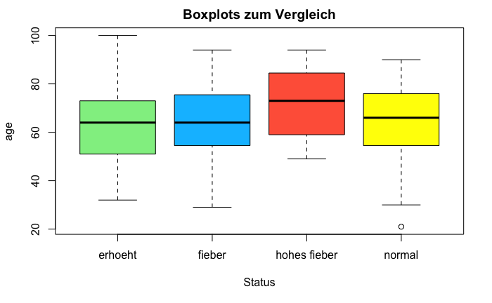

```r
boxplot(hosp6$age ~ hosp6$fever, #erst die AV, dann die UV

main = "Boxplots zum Vergleich", ylab = "age", xlab= "Status" , # Beschriftung des Boxplots

col = c("lightgreen", "deepskyblue","tomato", "yellow")) # Farben
```

Es liegen kaum Ausreißer vor. Es zeichnen sich Unterschied in den zentralen Tendenz ab, wobei insgesammt keine großen Unterschiede und Überschneidungen der Werte zu erkennen sind.

### Prüfung der Normalverteilung

#### Histogramm

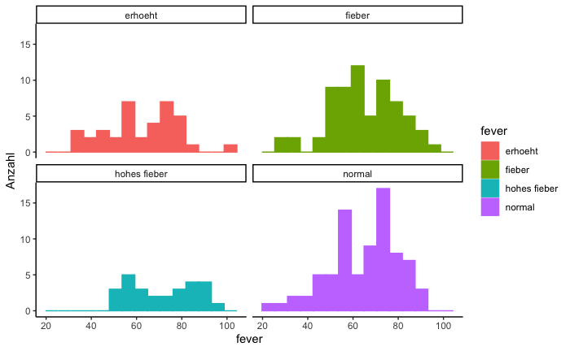

```r
hosp6 %>%
group_by(fever) %>% #Teilung nach UV
ggplot(aes(age, color=fever)) + # Die Werte
geom_histogram(aes(fill = fever), bins = 15) + # ggplot ist ein histogramm + Teilung für die Legende + breaks/bin sind 12
facet_wrap(~fever) + # drei Histogramm
theme_classic()+ # Farbe
labs(x= "fever",y = "Anzahl" )#Beschriftung
```

#### QQPlot

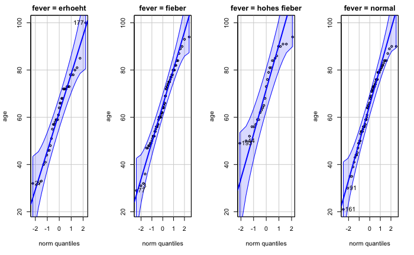

```r
library(car)

qqPlot(age ~ fever, data=hosp6,
layout=c(1,4))
```

Es handelt sich bei der Anova um ein sehr robustes Verfahren. Daher ist die Verletztung der Normalverteilung im kleinen Rahmen vertragbar. In diesem Beispiel zeigt es sich, dass die Normalverteilung bei vier Gruppen von der Tendenz gegeben ist.

## 4) Deskriptive Statistiken

Die Tabelle in Abbildung gibt die Mittelwerte, Standardabweichungen und Grössen aller vier Gruppen wieder. Diese Informationen werden für die Berichterstattung verwendet.

```r
library (dplyr)
hosp6 %>%
group_by(fever) %>%
  summarise(Anzahl = n(), Mittelwert = mean(age), Median = median(age), Standardabweichung = sd(age)) %>%
  mutate_if(is.numeric, round, 2)
```

| fever | Anzahl | Mittelwert | Median | Standardabweichung |
| --- | --- | --- | --- | --- |
| erhoeht | 37 | 62.08 | 64 | 15.95 |
| fieber | 67 | 64.55 | 64 | 14.93 |
| hohes fieber | 27 | 72.04 | 73 | 14.59 |
| normal | 79 | 64.77 | 66 | 15.17 |

## 5) Prüfung der Varianzhomogenität (Levene-Test)

Der Levene-Test prüft die Nullhypothese, dass die Varianzen der Gruppen sich nicht unterscheiden. Ist der Levene-Test nicht signifikant, so kann von homogenen Varianzen ausgegangen. Wäre der Levene-Test jedoch signifikant, so wäre eine der Grundvoraussetzungen der Varianzanalyse verletzt. Gegen leichte Verletzungen gilt die Varianzanalyse als robust; vor allem bei genügend grossen und etwa gleich grossen Gruppen sind Verletzungen nicht problematisch. Bei ungleich grossen Gruppen führt eine starke Verletzung der Varianzhomogenität zu einer Verzerrung des F-Tests. Alternativ können dann auf den Welch-Test zurückgegriffen werden. Dabei handelt es sich um adjustierte F-Tests.

```r
leveneTest(hosp6$age ~ hosp6$fever, center="mean")
```

```
Levene's Test for Homogeneity of Variance (center = "mean")
       Df F value Pr(>F)
group   3  0.1097 0.9543
      206
```

## 6) Ergebnisse der einfaktoriellen Varianzanalyse

```r
ANOVAhosp <- aov(data=hosp6, hosp6$age~hosp6$fever)
summary (ANOVAhosp)
```

```
             Df Sum Sq Mean Sq F value Pr(>F)
hosp6$fever   3   1664   554.8   2.413 0.0678 .
Residuals   206  47358   229.9
---
Signif. codes:  0 ‘***’ 0.001 ‘**’ 0.01 ‘*’ 0.05 ‘.’ 0.1 ‘ ’ 1
```

## 7) Post-hoc-Tests

Obwohl der F -Test zeigt, dass es keinen Zusammenhang zwischen dem Faktor von der Körpertemperatur und dem Alter gibt prüfen wir anhand des Post-hoc-Tests ob, zwischen einzelnen Faktorstufen (Körpertemperaturen “fever”) signifikante Unterschiede bezüglich des Alters gibt. Bei der Berechnung von Post-hoc-Tests wird im Prinzip für jede Kombination von zwei Mittelwerten ein t -Test durchgeführt. Im aktuellen Beispiel mit vier Gruppen errechnet man wie folgt 6 Tests.

$$\frac{k\cdot(k-1)}{2} =\frac{4\cdot(4-1)}{2} = \frac{12}{2} = 6$$
Multiple Tests sind jedoch problematisch, da der Alpha-Fehler (die fälschliche Ablehnung der Nullhypothese) mit der Anzahl der Vergleiche steigt. Diese Fehlerwahrscheinlichkeit wird als “Familywise Error Rate” bezeichnet.

Der TuckyHSD eignet sich als Post-toc-Test für die Vartiablen bei denen Varianzhomogenität vorliegt. Wenn der Levene-Test auf Heterogenität hingewiesen hätte wäre der Games-Howell-Test sinnvoller zu verwenden.

```r
TUKEYhosp<- TukeyHSD(aov(data=hosp6, hosp6$age ~ hosp6$fever))
TUKEYhosp
```

```
  Tukey multiple comparisons of means
    95% family-wise confidence level

Fit: aov(formula = hosp6$age ~ hosp6$fever, data = hosp6)

$`hosp6$fever`
                           diff          lwr       upr     p adj
fieber-erhoeht        2.4711577  -5.57267382 10.514989 0.8563262
hohes fieber-erhoeht  9.9559560   0.01583192 19.896080 0.0494688
normal-erhoeht        2.6910708  -5.13239425 10.514536 0.8095747
hohes fieber-fieber   7.4847982  -1.46738998 16.436986 0.1364045
normal-fieber         0.2199131  -6.30252614  6.742352 0.9997606
normal-hohes fieber  -7.2648851 -16.01960121  1.489831 0.1411906
```

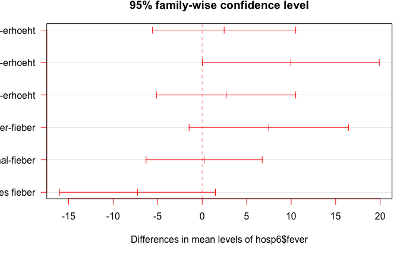

```r
plot(TUKEYhosp , las=1 , col="red")
```

## 8) Profildiagramm

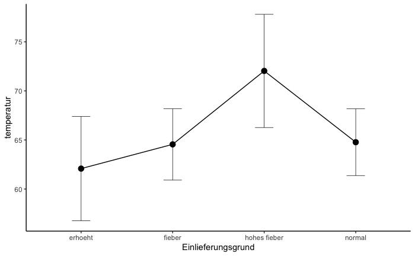

```r
library (ggplot2)
ggplot(hosp6, aes(x=fever, y=age, group=1))+
  stat_summary(fun = mean, geom="point", size=3)+
  stat_summary(fun = mean, geom="line")+
  stat_summary(fun.data = mean_cl_normal, geom="errorbar",width=.2, size=.25)+
  labs(x="Einlieferungsgrund", y="temperatur")+
  theme_classic()
```

## 9) Berechnung der Effektstärke

### Das partielle Eta-Quadrat

Das partielle Eta-Quadrat (partielles η2) ist ein Mass für die Effektgrösse: Es setzt die Variation, die durch einen Faktor erklärt wird, in Bezug mit jener Variation, die nicht durch andere Faktoren im Modell erklärt wird. Das heisst, es wird ausschliesslich jene Variation betrachtet, welche nicht durch die anderen Faktoren im Modell erklärt wird. Das partielle Eta-Quadrat zeigt, welchen Anteil davon ein Faktor erklärt. Im Falle der einfaktoriellen Varianzanalyse ist das partielle Eta-Quadrat ist jener Anteil der korrigierten Gesamtvariation, der durch das Modell erklärt wird.

```r
library(effectsize)

ANOVAhosp <- aov(data=hosp6, hosp6$age ~ hosp6$fever)
eta <- effectsize::eta_squared(ANOVAhosp, partial = TRUE)
```

```
For one-way between subjects designs, partial eta squared is equivalent to eta squared.
Returning eta squared.
```

```r
eta
```

```
# Effect Size for ANOVA

Parameter   | Eta2 |       95% CI
---------------------------------
hosp6$fever | 0.03 | [0.00, 1.00]

- One-sided CIs: upper bound fixed at (1).
```

Hinweis: Im vorliegenden Beispiel beträgt das partielle Eta-Quadrat $0.03$. Das heisst, dass mit diesen Daten theoretisch 3% der Variation in Alter durch die Körpertemperatur aufgeklärt werden kann.Da das Gesamtmodell jedoch nicht signifikant ist, kann hier keine sinnvolle Interpretation der Ergebnisse erfolgen. Wir haben trotzedem der Vollständigkeit halber die Effektstärke berrechnet.

### Effektstärke

```r
eff<- sqrt(eta$Eta2/(1-eta$Eta2))
sprintf ("Die Effektstärke liegt bei:%.2f",eff)
```

```
[1] "Die Effektstärke liegt bei:0.19"
```

Um zu beurteilen, wie gross dieser Effekt ist, kann man sich an der Einteilung von Cohen (1988) orientieren:

$$\begin{align}
\text{Schwacher Effekt: } 0.10 &< ||f|| < 0.25 \\
\text{Schwacher bis mittlerer Effekt: } 0.25 &= ||f|| \\
\text{Mittlerer Effekt: } 0.25 &< ||f|| < 0.40 \\
\text{Mittlerer bis starker Effekt: }0.40 &= ||f|| \\
\text{Starker Effekt: } 0.40 &< ||f||
\end{align}$$

Damit entspricht eine Effektstärke von $0.19$ einem schwachen Effekt. Dies ist allerdings nur theoretisch, da eine Interpretation der Daten aufgrund der nicht vorhandenen Signifikanz der Varianzanlyse keine sinnvolle Interpretation der Daten möglich ist.